# Final Assignment: Wage Data and Decision Trees Algorithm

21 de octubre de 2020

## Context

The Shiny application runs a predictive algorithm using the 'Wage' dataset corresponding to the library 'ISLR'. For that, it is used the **train()** function from the caret package with the method **rpart** to estimate a decision tree algorithm.

The application estimates the *Wage Group* variable, what is defined as the result of the **cutwage()** function from the **Hmisc** package applied to the Wage variable.

See the variables of the data:

```
##  [1] "year"       "age"        "maritl"     "race"       "education"
##  [6] "region"     "jobclass"   "health"     "health_ins" "logwage"
## [11] "wage"
```

## Interactivity

The user can change the following parameters of the data and/or of the algorithm:

1. Wage: the user can change the range of the values in the wage variable (min and max values) between 20.09 and 318.34.
2. Data partition parameter: the user can change the data partition parameter (between 0.4 and 0.9) used in the **createDataPartition()** function, i.e, the proportion of the data used for the training set versus the testing set.
3. Number of groups: the user can change the number of wage groups, that is the dependent variable estimated by the algorithm. The user can change between 2 and 5 groups.

## Results 1

Example 1: 3 groups, total data and p=0.7

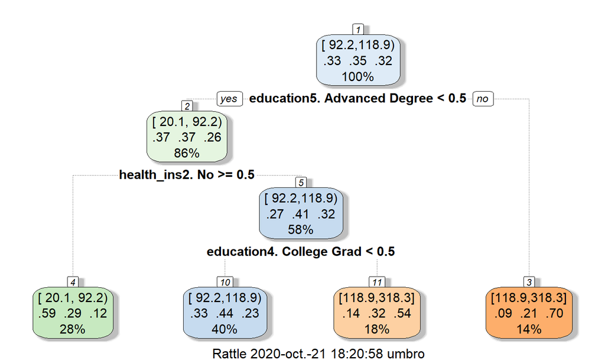

## Results 2

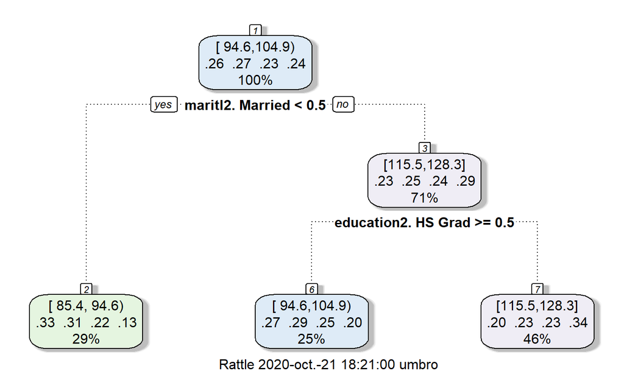